# Demos from O’Reilly’s Learning R (Richard Cotton)

Steven Troxler

December 1, 2015

```r
library(ggplot2)
library(dplyr)
```

The later chapters of *Learning R* have some cool demos of working with data. Here I try to capture some of the most interesting practical examples which aren’t in other tutorials I’ve worked through.

Most of the demos here involve input/output, although at the bottom there’s a short blurb on plotting.

# Reading and writing data

Almost all R tutorials discuss `read.table`, `write.table`, `read.csv`, and `write.csv` for delimited tables. Here we discuss some of the other forms of data IO covered by *Learning R*.

## Plain text

Use `readLines` to read plain-text files that can fit in memory; this is akin to `python`s `with open(path, 'r') as f: f.readlines()`:

```r
setwd("~/lp/R/learningr/")
plain_text_path <- system.file("extdata",
                               "Shakespeare's The Tempest, from Project Gutenberg pg2235.txt",
                               package="learningr")
my_text <- readLines("a_plain_text_file.txt")
my_text
```

```
## [1] "Here is a plain"
## [2] "text file, which we can read using readLines"
## [3] "and write using writeLines"
```

We can write using `writeLines`, which prints to stdout by default but writes in “w” mode if you give it a path

```r
writeLines(my_text, "another_text_file.txt")
```

To write a single large string to a file, use `cat()`, which like `writeLines` defaults to `stdout` but optionally accepts a path as its second argument.

## XML

When you read XML using the `XML` library, you get back documents with a special type. If you add `useInternalNodes = FALSE` to the call, you’ll be able to use `str` and `head` to view the document. That said, the output is extremely verbose, so we suppress the output here

```r
xml_path <- system.file("extdata", "options.xml", package="learningr")
r_options <- XML::xmlParse(xml_path)
# can't use str(r_options) / head(r_options)
r_options <- XML::xmlParse(xml_path, useInternalNodes = FALSE)
# we comment this out because it's too verbose, but this will work:
# head(r_options)
```

There is also an `xmlTreeParse` function, which is like `xmlParse` with `useInternalNodes = FALSE` by default.

You can work with XML using the XPath language, using the `XML::xpathSApply` function. There’s a lot of other xml functionality, but most of it is hard to learn without a real problem to work on.

If you need to write R data to an xml file (for example so that another tool or language can read it), the `XML` package won’t help, but `RUniversal::makexml` will: you can apply it to a list and it will output a string; you can then use `cat` to write it to a file. (This, the author points out, is how he made `options.xml` in the first place.)

## Json

There are two main packages for working with json, `rjson` and `RJSONIO`. Since they are similar (they differ in how they handle NA / NaN), I’ll just demo `rjson`, which prefers to work with in-memory strings (`RJSONIO`, like `XML`, likes to read directly from file).

To convert an R object to json, use `rjson::toJSON`:

```r
sample_data_frame <- data.frame(var1 = c(2, 3, 4), var1 = c("cat", "cat", "dog"))
json1 <- rjson::toJSON(
  list(x = c(1, 2, 4, NA), y = NaN, z = list(a = 5, b = "hello")))
json2 <- rjson::toJSON(sample_data_frame)
json1
```

```
## [1] "{\"x\":[1,2,4,\"NA\"],\"y\":\"NaN\",\"z\":{\"a\":5,\"b\":\"hello\"}}"
```

To convert json back to R, use `rjson::fromJSON`:

```r
rjson::fromJSON(json1)
```

```
## $x
## $x[[1]]
## [1] 1
##
## $x[[2]]
## [1] 2
##
## $x[[3]]
## [1] 4
##
## $x[[4]]
## [1] "NA"
##
##
## $y
## [1] "NaN"
##
## $z
## $z$a
## [1] 5
##
## $z$b
## [1] "hello"
```

```r
rjson::fromJSON(json2)
```

```
## $var1
## [1] 2 3 4
##
## $var1.1
## [1] "cat" "cat" "dog"
```

Note that to reconstruct our `NA` and `NaN` observations, we would need to convert them explicitly. To reconstruct a data frame you dumped as json, wrap the `fromJSON` call in an `as.data.frame`:

```r
as.data.frame(rjson::fromJSON(json2))
```

```
##   var1 var1.1
## 1    2    cat
## 2    3    cat
## 3    4    dog
```

## Yaml

You can read yaml from a file using `yaml::load_file(file_path)`; you can similarly load yaml strings. You can dump an R object to yaml using `yaml::as.yaml`.

## Records

The way that R converts `data.frame`s to `list`s is natural given how R works, but it is counterproductive for working with many other tools like D3: these tools tend to expect tabular data to be formed as lists of maps. In the `pydata` stack, the `DataFrame` class has methods `to_records` and `from_records` to make this conversion easy.

Here, we define a `to_records` function for R. The `from_records` case is a bit harder to write, and slightly less likely to be important so we omit it.

```r
to_records <- function(df) {
  records <- split(df, seq(nrow(df)))
  names(records) <- NULL
  records
}
rjson::toJSON(to_records(sample_data_frame))
```

```
## [1] "[{\"var1\":2,\"var1.1\":\"cat\"},{\"var1\":3,\"var1.1\":\"cat\"},{\"var1\":4,\"var1.1\":\"dog\"}]"
```

## SQL

We first open a connection. We will use the `sqldf` package to work with sqlite, although a very similar api can be used for other sql databases.

```r
library('sqldf')
```

```r
setwd('~/lp/R/learningr/')
system('bash make_demo_db.sh')
db <- dbConnect(SQLite(), dbname="example.sqlite")
```

We can then read a full table in one shot

```r
dbReadTable(db, 'mytable')
```

```
##   label value
## 1    me    10
## 2   you    20
```

We can update the table using a query (there are probably better ways to do this from data frames, but for this demo we’ll stick with straight SQL)

```r
ignore = dbSendQuery(db, 'insert into mytable (label, value) values ("her", 15.3);')
```

And we can also fetch the results of a query which isn’t a full table:

```r
queryResult = dbSendQuery(db, 'select * from mytable where value > 12;')
dbFetch(queryResult)
```

```
##   label value
## 1   you  20.0
## 2   her  15.3
```

## Other important file formats

I won’t go into examples now, but R has packages that make it easy to read data from MS Excel files, HDF5 archives, matlab files, and SAS files.

Most other data sources (mongodb, redshift, etc) likely also have R packages; above I just list the ones I know for certain.

# Plotting

I have already made examples of most of the plots from the plotting chapter of *Learning R*, but I do want to go through the demonstration of a bar chart with two independent variables.

Take a look at the mtcars dataset:

```r
tbl_df(mtcars)
```

```
## Source: local data frame [32 x 11]
##
##      mpg   cyl  disp    hp  drat    wt  qsec    vs    am  gear  carb
##    (dbl) (dbl) (dbl) (dbl) (dbl) (dbl) (dbl) (dbl) (dbl) (dbl) (dbl)
## 1   21.0     6 160.0   110  3.90 2.620 16.46     0     1     4     4
## 2   21.0     6 160.0   110  3.90 2.875 17.02     0     1     4     4
## 3   22.8     4 108.0    93  3.85 2.320 18.61     1     1     4     1
## 4   21.4     6 258.0   110  3.08 3.215 19.44     1     0     3     1
## 5   18.7     8 360.0   175  3.15 3.440 17.02     0     0     3     2
## 6   18.1     6 225.0   105  2.76 3.460 20.22     1     0     3     1
## 7   14.3     8 360.0   245  3.21 3.570 15.84     0     0     3     4
## 8   24.4     4 146.7    62  3.69 3.190 20.00     1     0     4     2
## 9   22.8     4 140.8    95  3.92 3.150 22.90     1     0     4     2
## 10  19.2     6 167.6   123  3.92 3.440 18.30     1     0     4     4
## ..   ...   ...   ...   ...   ...   ...   ...   ...   ...   ...   ...
```

We are going to demonstrate bar charts of the number of observations versus the number of cylenders and carburetors. To form a stacked bar chart, just set (in `aes`) `x` to the main variable you want to use, and `fill` to the secondary variable:

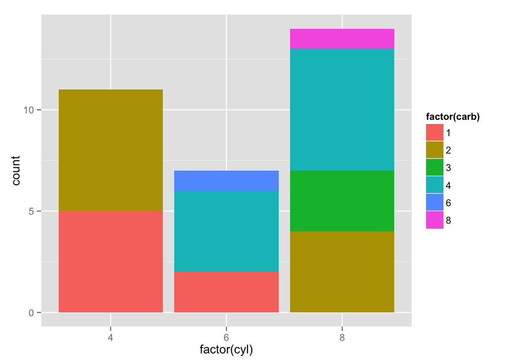

```r
ggplot(mtcars, aes(x=factor(cyl), fill=factor(carb))) +
    geom_bar()
```

If you prefer a non-stacked barplot, you add `position = "dodge"` to the `geom_bar` definition, which causes it to place the bars side-by-side rather than stacked:

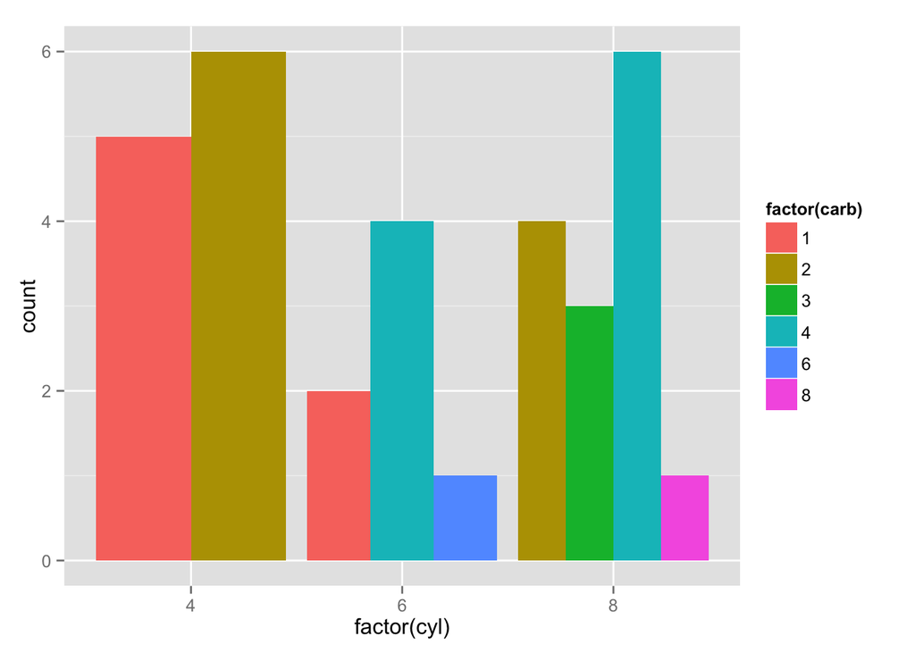

```r
ggplot(mtcars, aes(x=factor(cyl), fill=factor(carb))) +
    geom_bar(position="dodge")
```

A general note on bar plots that came up when I was searching for examples: by default, the `aes` call only needs an `x`, in which case the `y` is implicitly the count of the number of rows.

# Modeling

We will demo some of R’s linear modelling abilities on the `gonorrhoea` dataset from the `learningr` package:

```r
gonorrhoea <- tbl_df(learningr::gonorrhoea)
gonorrhoea
```

```
## Source: local data frame [600 x 5]
##
##     Year Age.Group           Ethnicity Gender  Rate
##    (int)    (fctr)              (fctr) (fctr) (dbl)
## 1   2007    0 to 4 Non-Hispanic Whites   Male   0.3
## 2   2007    5 to 9 Non-Hispanic Whites   Male   0.0
## 3   2007  10 to 14 Non-Hispanic Whites   Male   0.2
## 4   2007  15 to 19 Non-Hispanic Whites   Male  31.0
## 5   2007  20 to 24 Non-Hispanic Whites   Male  76.9
## 6   2007  25 to 29 Non-Hispanic Whites   Male  63.4
## 7   2007  30 to 34 Non-Hispanic Whites   Male  41.0
## 8   2007  35 to 39 Non-Hispanic Whites   Male  31.8
## 9   2007  40 to 44 Non-Hispanic Whites   Male  25.4
## 10  2007  45 to 54 Non-Hispanic Whites   Male  13.7
## ..   ...       ...                 ...    ...   ...
```

This dataset, in addition to having some quantitative variables, also has several `factors`, or qualitative variables. Let’s take a look… The `Filter` builtin function filters the columns of a data frame by a predicate (oddly, there’s no easy equivalent in `dplyr`; perhaps this reflects that R naturally likes operating on the columns of data frames, so `dplyr` focuses on row operations), and `lapply` works on columns when applied to data frames

```r
lapply(Filter(is.factor, gonorrhoea), levels)
```

```
## $Age.Group
##  [1] "0 to 4"     "5 to 9"     "10 to 14"   "15 to 19"   "20 to 24"
##  [6] "25 to 29"   "30 to 34"   "35 to 39"   "40 to 44"   "45 to 54"
## [11] "55 to 64"   "65 or more"
##
## $Ethnicity
## [1] "American Indians & Alaskan Natives"
## [2] "Asians & Pacific Islanders"
## [3] "Hispanics"
## [4] "Non-Hispanic Blacks"
## [5] "Non-Hispanic Whites"
##
## $Gender
## [1] "Female" "Male"
```

Running a model: We can create a model and get a first look at it with the `summary` function - which is actually an `s3` method and overloaded for many different R objects:

```r
model1 <- lm(Rate ~ Year + Age.Group + Ethnicity + Gender, gonorrhoea)
summary(model1)
```

```
##
## Call:
## lm(formula = Rate ~ Year + Age.Group + Ethnicity + Gender, data = gonorrhoea)
##
## Residuals:
##     Min      1Q  Median      3Q     Max
## -376.74 -130.62   37.12   90.69 1467.06
##
## Coefficients:
##                                      Estimate Std. Error t value Pr(>|t|)
## (Intercept)                          5540.496  14866.406   0.373  0.70952
## Year                                   -2.770      7.400  -0.374  0.70826
## Age.Group5 to 9                        -0.614     51.268  -0.012  0.99045
## Age.Group10 to 14                      15.268     51.268   0.298  0.76596
## Age.Group15 to 19                     415.698     51.268   8.108 3.05e-15
## Age.Group20 to 24                     546.820     51.268  10.666  < 2e-16
## Age.Group25 to 29                     291.098     51.268   5.678 2.15e-08
## Age.Group30 to 34                     155.872     51.268   3.040  0.00247
## Age.Group35 to 39                      84.612     51.268   1.650  0.09940
## Age.Group40 to 44                      49.506     51.268   0.966  0.33463
## Age.Group45 to 54                      27.364     51.268   0.534  0.59372
## Age.Group55 to 64                       8.684     51.268   0.169  0.86555
## Age.Group65 or more                     1.178     51.268   0.023  0.98168
## EthnicityAsians & Pacific Islanders   -82.922     33.093  -2.506  0.01249
## EthnicityHispanics                    -49.000     33.093  -1.481  0.13924
## EthnicityNon-Hispanic Blacks          376.204     33.093  11.368  < 2e-16
## EthnicityNon-Hispanic Whites          -68.263     33.093  -2.063  0.03958
## GenderMale                            -17.892     20.930  -0.855  0.39298
##
## (Intercept)
## Year
## Age.Group5 to 9
## Age.Group10 to 14
## Age.Group15 to 19                   ***
## Age.Group20 to 24                   ***
## Age.Group25 to 29                   ***
## Age.Group30 to 34                   **
## Age.Group35 to 39                   .
## Age.Group40 to 44
## Age.Group45 to 54
## Age.Group55 to 64
## Age.Group65 or more
## EthnicityAsians & Pacific Islanders *
## EthnicityHispanics
## EthnicityNon-Hispanic Blacks        ***
## EthnicityNon-Hispanic Whites        *
## GenderMale
## ---
## Signif. codes:  0 '***' 0.001 '**' 0.01 '*' 0.05 '.' 0.1 ' ' 1
##
## Residual standard error: 256.3 on 582 degrees of freedom
## Multiple R-squared:  0.4913, Adjusted R-squared:  0.4765
## F-statistic: 33.07 on 17 and 582 DF,  p-value: < 2.2e-16
```

If you `plot()` a model, it will cycle through diagnostic plots. The following function, `plot_model`, uses `layout` to make all these plots at once:

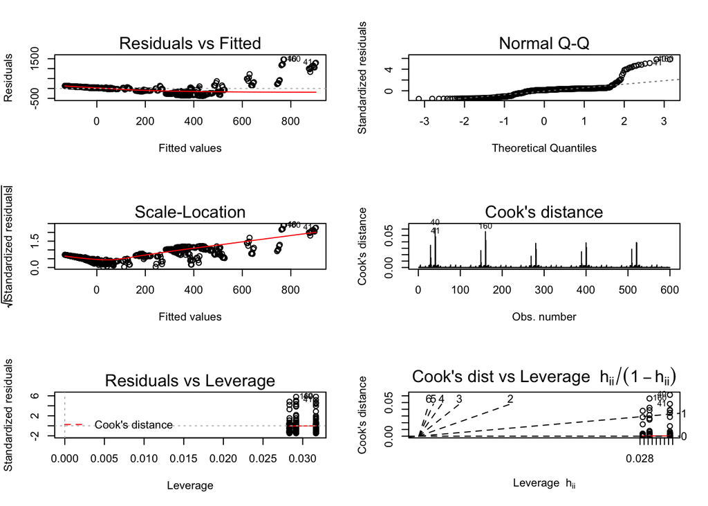

```r
plot_model <- function(mod) {
  plot_numbers <- 1:6
  layout(matrix(plot_numbers, ncol = 2, byrow = TRUE))
  plot(mod, plot_numbers)
}
plot_model(model1)
```

A detailed understanding of these diagnostics is beyond the scope of this tutorial (look in a book on linear models), but note that Cook’s distance can be useful for finding outliers; in our data, rows 40, 41, and 160 have been flagged as outliers.

Note that if you wanted to poke around the internals of a `model`, you could run the `str` and `unclass` methods to see what’s in it. They are fairly big, with lots of metadata.

We’ll demo one other diagnostic plot from the *Learning R* book, a plot of residual versus fitted value:

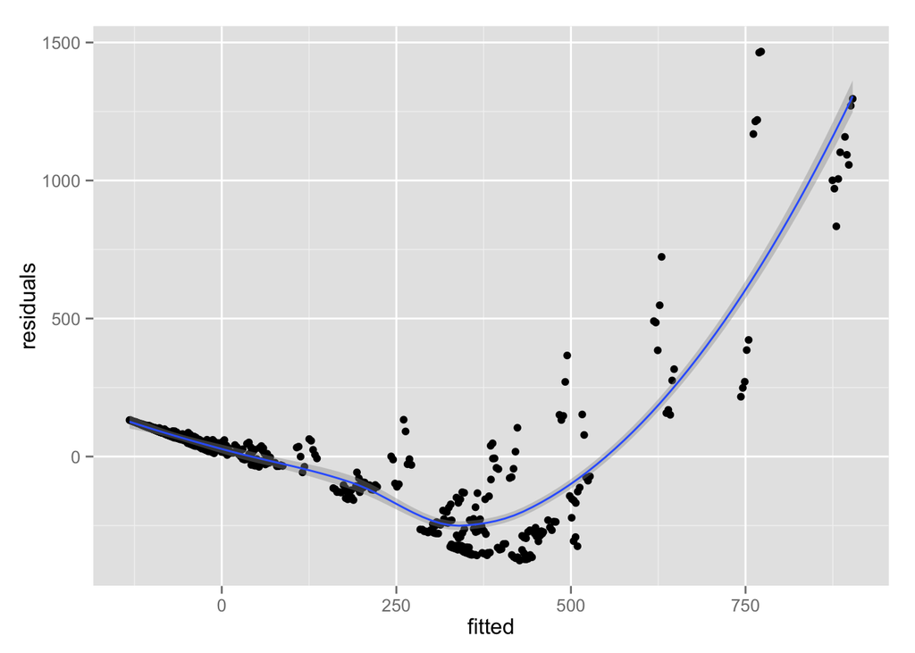

```r
diagnostics <- data.frame(
  residuals = residuals(model1),
  fitted = fitted(model1)
)
ggplot(diagnostics) + aes(fitted, residuals) + geom_point() +
  geom_smooth(method = "loess")
```

From this plot, we can see that the model errors seem to follow a U-shaped pattern with respect to the fitted values, suggesting that a linear model may not be appropriate.

We’ll leave off with a discussion of building additional models and comparing models. Let’s try removing `Year` from `model1` to get a simpler model:

```r
model2 = update(model1, ~ . - Year)
summary(model2)
```

```
##
## Call:
## lm(formula = Rate ~ Age.Group + Ethnicity + Gender, data = gonorrhoea)
##
## Residuals:
##     Min      1Q  Median      3Q     Max
## -377.59 -128.45   34.64   92.22 1472.60
##
## Coefficients:
##                                     Estimate Std. Error t value Pr(>|t|)
## (Intercept)                          -25.104     43.117  -0.582  0.56064
## Age.Group5 to 9                       -0.614     51.230  -0.012  0.99044
## Age.Group10 to 14                     15.268     51.230   0.298  0.76579
## Age.Group15 to 19                    415.698     51.230   8.114 2.91e-15
## Age.Group20 to 24                    546.820     51.230  10.674  < 2e-16
## Age.Group25 to 29                    291.098     51.230   5.682 2.10e-08
## Age.Group30 to 34                    155.872     51.230   3.043  0.00245
## Age.Group35 to 39                     84.612     51.230   1.652  0.09915
## Age.Group40 to 44                     49.506     51.230   0.966  0.33427
## Age.Group45 to 54                     27.364     51.230   0.534  0.59345
## Age.Group55 to 64                      8.684     51.230   0.170  0.86545
## Age.Group65 or more                    1.178     51.230   0.023  0.98166
## EthnicityAsians & Pacific Islanders  -82.922     33.069  -2.508  0.01243
## EthnicityHispanics                   -49.000     33.069  -1.482  0.13894
## EthnicityNon-Hispanic Blacks         376.204     33.069  11.376  < 2e-16
## EthnicityNon-Hispanic Whites         -68.263     33.069  -2.064  0.03943
## GenderMale                           -17.892     20.915  -0.855  0.39263
##
## (Intercept)
## Age.Group5 to 9
## Age.Group10 to 14
## Age.Group15 to 19                   ***
## Age.Group20 to 24                   ***
## Age.Group25 to 29                   ***
## Age.Group30 to 34                   **
## Age.Group35 to 39                   .
## Age.Group40 to 44
## Age.Group45 to 54
## Age.Group55 to 64
## Age.Group65 or more
## EthnicityAsians & Pacific Islanders *
## EthnicityHispanics
## EthnicityNon-Hispanic Blacks        ***
## EthnicityNon-Hispanic Whites        *
## GenderMale
## ---
## Signif. codes:  0 '***' 0.001 '**' 0.01 '*' 0.05 '.' 0.1 ' ' 1
##
## Residual standard error: 256.1 on 583 degrees of freedom
## Multiple R-squared:  0.4912, Adjusted R-squared:  0.4772
## F-statistic: 35.18 on 16 and 583 DF,  p-value: < 2.2e-16
```

We can compare the two models using `F` statistics via the `anova` function

```r
anova(model1, model2)
```

```
## Analysis of Variance Table
##
## Model 1: Rate ~ Year + Age.Group + Ethnicity + Gender
## Model 2: Rate ~ Age.Group + Ethnicity + Gender
##   Res.Df      RSS Df Sum of Sq      F Pr(>F)
## 1    582 38243062
## 2    583 38252272 -1   -9209.7 0.1402 0.7083
```

```r
AIC(model1, model2)
```

```
##        df      AIC
## model1 19 8378.252
## model2 18 8376.397
```

```r
BIC(model1, model2)
```

```
##        df      BIC
## model1 19 8461.794
## model2 18 8455.541
```

There are many more things we can do with models, and the `glm` function provides a huge addition of models with similar diagnostics to what `lm` has. But since this tutorial is more about R basics than linear models, we will stop here.